# Risk Factor Analysis

## Outcome Variable

**Outcome Variable:** whz

## Predictor Variables

**Intervention Variable:** mhtcm

**Adjustment Set:**

- arm
- W_mage
- meducyrs
- feducyrs
- single
- impsan
- W_gagebrth
- W_birthwt
- W_birthlen
- vagbrth
- parity
- delta_W_mage
- delta_meducyrs
- delta_feducyrs
- delta_single
- delta_impsan
- delta_W_gagebrth
- delta_W_birthwt
- delta_W_birthlen
- delta_vagbrth
- delta_parity

## Stratifying Variables

The analysis was stratified on these variable(s):

- agecat
- studyid
- country

## Data Summary

| agecat | studyid | country | mhtcm | n_cell | n |
| --- | --- | --- | --- | --- | --- |
| 6 months | ki0047075b-MAL-ED | BANGLADESH | >=155 cm | 24 | 241 |
| 6 months | ki0047075b-MAL-ED | BANGLADESH | <151 cm | 156 | 241 |
| 6 months | ki0047075b-MAL-ED | BANGLADESH | [151-155) cm | 61 | 241 |
| 6 months | ki0047075b-MAL-ED | BRAZIL | >=155 cm | 121 | 209 |
| 6 months | ki0047075b-MAL-ED | BRAZIL | <151 cm | 51 | 209 |
| 6 months | ki0047075b-MAL-ED | BRAZIL | [151-155) cm | 37 | 209 |
| 6 months | ki0047075b-MAL-ED | INDIA | >=155 cm | 55 | 235 |
| 6 months | ki0047075b-MAL-ED | INDIA | <151 cm | 112 | 235 |
| 6 months | ki0047075b-MAL-ED | INDIA | [151-155) cm | 68 | 235 |
| 6 months | ki0047075b-MAL-ED | NEPAL | >=155 cm | 41 | 236 |
| 6 months | ki0047075b-MAL-ED | NEPAL | <151 cm | 132 | 236 |
| 6 months | ki0047075b-MAL-ED | NEPAL | [151-155) cm | 63 | 236 |
| 6 months | ki0047075b-MAL-ED | PERU | >=155 cm | 58 | 272 |
| 6 months | ki0047075b-MAL-ED | PERU | <151 cm | 157 | 272 |
| 6 months | ki0047075b-MAL-ED | PERU | [151-155) cm | 57 | 272 |
| 6 months | ki0047075b-MAL-ED | SOUTH AFRICA | >=155 cm | 187 | 249 |
| 6 months | ki0047075b-MAL-ED | SOUTH AFRICA | <151 cm | 31 | 249 |
| 6 months | ki0047075b-MAL-ED | SOUTH AFRICA | [151-155) cm | 31 | 249 |
| 6 months | ki0047075b-MAL-ED | TANZANIA, UNITED REPUBLIC OF | >=155 cm | 147 | 247 |
| 6 months | ki0047075b-MAL-ED | TANZANIA, UNITED REPUBLIC OF | <151 cm | 48 | 247 |
| 6 months | ki0047075b-MAL-ED | TANZANIA, UNITED REPUBLIC OF | [151-155) cm | 52 | 247 |
| 6 months | ki1000304b-SAS-CompFeed | INDIA | >=155 cm | 509 | 1226 |
| 6 months | ki1000304b-SAS-CompFeed | INDIA | <151 cm | 421 | 1226 |
| 6 months | ki1000304b-SAS-CompFeed | INDIA | [151-155) cm | 296 | 1226 |
| 6 months | ki1000304b-SAS-FoodSuppl | INDIA | >=155 cm | 75 | 379 |
| 6 months | ki1000304b-SAS-FoodSuppl | INDIA | <151 cm | 202 | 379 |
| 6 months | ki1000304b-SAS-FoodSuppl | INDIA | [151-155) cm | 102 | 379 |
| 6 months | ki1017093-NIH-Birth | BANGLADESH | >=155 cm | 96 | 536 |
| 6 months | ki1017093-NIH-Birth | BANGLADESH | <151 cm | 310 | 536 |
| 6 months | ki1017093-NIH-Birth | BANGLADESH | [151-155) cm | 130 | 536 |

[output cut: 93 more lines]

The following strata were considered:

- agecat: 24 months, studyid: ki0047075b-MAL-ED, country: BANGLADESH
- agecat: 24 months, studyid: ki0047075b-MAL-ED, country: BRAZIL
- agecat: 24 months, studyid: ki0047075b-MAL-ED, country: INDIA
- agecat: 24 months, studyid: ki0047075b-MAL-ED, country: NEPAL
- agecat: 24 months, studyid: ki0047075b-MAL-ED, country: PERU
- agecat: 24 months, studyid: ki0047075b-MAL-ED, country: SOUTH AFRICA
- agecat: 24 months, studyid: ki0047075b-MAL-ED, country: TANZANIA, UNITED REPUBLIC OF
- agecat: 24 months, studyid: ki1017093-NIH-Birth, country: BANGLADESH
- agecat: 24 months, studyid: ki1017093b-PROVIDE, country: BANGLADESH
- agecat: 24 months, studyid: ki1017093c-NIH-Crypto, country: BANGLADESH
- agecat: 24 months, studyid: ki1066203-TanzaniaChild2, country: TANZANIA, UNITED REPUBLIC OF
- agecat: 24 months, studyid: ki1101329-Keneba, country: GAMBIA
- agecat: 24 months, studyid: ki1119695-PROBIT, country: BELARUS
- agecat: 24 months, studyid: ki1126311-ZVITAMBO, country: ZIMBABWE
- agecat: 24 months, studyid: ki1135781-COHORTS, country: GUATEMALA
- agecat: 24 months, studyid: ki1135781-COHORTS, country: INDIA
- agecat: 24 months, studyid: ki1135781-COHORTS, country: PHILIPPINES
- agecat: 24 months, studyid: ki1148112-LCNI-5, country: MALAWI
- agecat: 24 months, studyid: kiGH5241-JiVitA-3, country: BANGLADESH
- agecat: 6 months, studyid: ki0047075b-MAL-ED, country: BANGLADESH
- agecat: 6 months, studyid: ki0047075b-MAL-ED, country: BRAZIL
- agecat: 6 months, studyid: ki0047075b-MAL-ED, country: INDIA
- agecat: 6 months, studyid: ki0047075b-MAL-ED, country: NEPAL
- agecat: 6 months, studyid: ki0047075b-MAL-ED, country: PERU
- agecat: 6 months, studyid: ki0047075b-MAL-ED, country: SOUTH AFRICA
- agecat: 6 months, studyid: ki0047075b-MAL-ED, country: TANZANIA, UNITED REPUBLIC OF
- agecat: 6 months, studyid: ki1000304b-SAS-CompFeed, country: INDIA
- agecat: 6 months, studyid: ki1000304b-SAS-FoodSuppl, country: INDIA
- agecat: 6 months, studyid: ki1017093-NIH-Birth, country: BANGLADESH
- agecat: 6 months, studyid: ki1017093b-PROVIDE, country: BANGLADESH
- agecat: 6 months, studyid: ki1017093c-NIH-Crypto, country: BANGLADESH
- agecat: 6 months, studyid: ki1066203-TanzaniaChild2, country: TANZANIA, UNITED REPUBLIC OF
- agecat: 6 months, studyid: ki1101329-Keneba, country: GAMBIA
- agecat: 6 months, studyid: ki1112895-Guatemala BSC, country: GUATEMALA
- agecat: 6 months, studyid: ki1119695-PROBIT, country: BELARUS
- agecat: 6 months, studyid: ki1126311-ZVITAMBO, country: ZIMBABWE
- agecat: 6 months, studyid: ki1135781-COHORTS, country: GUATEMALA
- agecat: 6 months, studyid: ki1135781-COHORTS, country: INDIA
- agecat: 6 months, studyid: ki1135781-COHORTS, country: PHILIPPINES
- agecat: 6 months, studyid: ki1148112-LCNI-5, country: MALAWI
- agecat: 6 months, studyid: kiGH5241-JiVitA-3, country: BANGLADESH

### Dropped Strata

Some strata were dropped due to rare outcomes:

- agecat: 24 months, studyid: ki1066203-TanzaniaChild2, country: TANZANIA, UNITED REPUBLIC OF

## Methods Detail

We’re interested in the causal parameters $E[Y_a]$ for all values of $a \in \mathcal{A}$. These parameters represent the mean outcome if, possibly contrary to fact, we intervened to set all units to have $A=a$. Under the randomization and positivity assumptions, these are identified by the statistical parameters $\psi_a=E_W[E_{Y|A,W}(Y|A=a,W)]$. In addition, we’re interested in the mean of $Y$, $E[Y]$ under no intervention (the observed mean). We will estimate these parameters by using SuperLearner to fit the relevant likelihood factors – $E_{Y|A,W}(Y|A=a,W)$ and $p(A=a|W)$, and then updating our likelihood fit using a joint TMLE.

For unadjusted analyses ($W=\{\}$), initial likelihoods were estimated using Lrnr_glm to estimate the simple $E(Y|A)$ and Lrnr_mean to estimate $p(A)$. For adjusted analyses, a small library containing Lrnr_glmnet, Lrnr_xgboost, and Lrnr_mean was used.

Having estimated these parameters, we will then use the delta method to estimate relative risks and attributable risks relative to a prespecified baseline level of $A$.

# Results Detail

## Results Plots

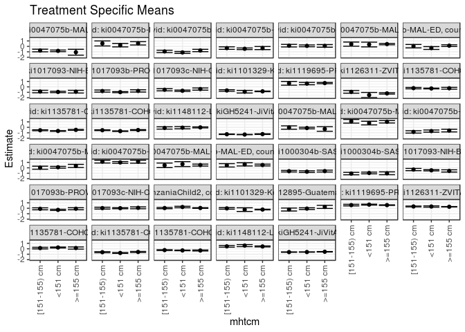

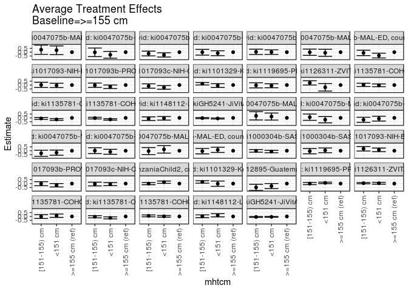

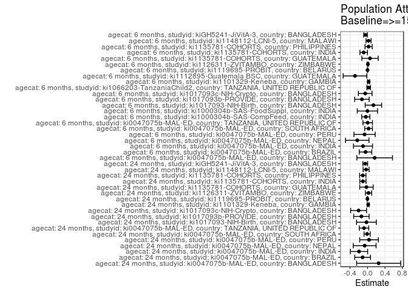

## Results Table

### Parameter: TSM

| agecat | studyid | country | intervention_level | baseline_level | estimate | ci_lower | ci_upper |
| --- | --- | --- | --- | --- | --- | --- | --- |
| 6 months | ki0047075b-MAL-ED | BANGLADESH | >=155 cm | NA | -0.3045277 | -0.7335200 | 0.1244645 |
| 6 months | ki0047075b-MAL-ED | BANGLADESH | <151 cm | NA | -0.1303398 | -0.2797488 | 0.0190692 |
| 6 months | ki0047075b-MAL-ED | BANGLADESH | [151-155) cm | NA | -0.0383089 | -0.3441439 | 0.2675262 |
| 6 months | ki0047075b-MAL-ED | BRAZIL | >=155 cm | NA | 1.0163702 | 0.7920995 | 1.2406410 |
| 6 months | ki0047075b-MAL-ED | BRAZIL | <151 cm | NA | 0.7828122 | 0.4469513 | 1.1186731 |
| 6 months | ki0047075b-MAL-ED | BRAZIL | [151-155) cm | NA | 1.1057302 | 0.7652696 | 1.4461908 |
| 6 months | ki0047075b-MAL-ED | INDIA | >=155 cm | NA | -0.5962754 | -0.8394069 | -0.3531440 |
| 6 months | ki0047075b-MAL-ED | INDIA | <151 cm | NA | -0.6905884 | -0.8874148 | -0.4937620 |
| 6 months | ki0047075b-MAL-ED | INDIA | [151-155) cm | NA | -0.8432323 | -1.0588843 | -0.6275804 |
| 6 months | ki0047075b-MAL-ED | NEPAL | >=155 cm | NA | 0.3447196 | 0.0529729 | 0.6364662 |
| 6 months | ki0047075b-MAL-ED | NEPAL | <151 cm | NA | 0.0977605 | -0.0690868 | 0.2646078 |
| 6 months | ki0047075b-MAL-ED | NEPAL | [151-155) cm | NA | 0.0188080 | -0.2593405 | 0.2969565 |
| 6 months | ki0047075b-MAL-ED | PERU | >=155 cm | NA | 1.1228348 | 0.8459972 | 1.3996725 |
| 6 months | ki0047075b-MAL-ED | PERU | <151 cm | NA | 0.9864944 | 0.8253762 | 1.1476125 |
| 6 months | ki0047075b-MAL-ED | PERU | [151-155) cm | NA | 1.1312761 | 0.8756003 | 1.3869520 |
| 6 months | ki0047075b-MAL-ED | SOUTH AFRICA | >=155 cm | NA | 0.5034121 | 0.3239179 | 0.6829062 |
| 6 months | ki0047075b-MAL-ED | SOUTH AFRICA | <151 cm | NA | 0.6823053 | 0.2332314 | 1.1313791 |
| 6 months | ki0047075b-MAL-ED | SOUTH AFRICA | [151-155) cm | NA | 0.4566319 | 0.0415737 | 0.8716900 |
| 6 months | ki0047075b-MAL-ED | TANZANIA, UNITED REPUBLIC OF | >=155 cm | NA | 0.5121131 | 0.3480090 | 0.6762172 |
| 6 months | ki0047075b-MAL-ED | TANZANIA, UNITED REPUBLIC OF | <151 cm | NA | 0.6292084 | 0.3347248 | 0.9236920 |
| 6 months | ki0047075b-MAL-ED | TANZANIA, UNITED REPUBLIC OF | [151-155) cm | NA | 0.4590284 | 0.1490307 | 0.7690262 |
| 6 months | ki1000304b-SAS-CompFeed | INDIA | >=155 cm | NA | -0.6043667 | -0.7757123 | -0.4330212 |
| 6 months | ki1000304b-SAS-CompFeed | INDIA | <151 cm | NA | -0.7076592 | -0.8579279 | -0.5573906 |
| 6 months | ki1000304b-SAS-CompFeed | INDIA | [151-155) cm | NA | -0.6202400 | -0.7604195 | -0.4800605 |
| 6 months | ki1000304b-SAS-FoodSuppl | INDIA | >=155 cm | NA | -1.0045526 | -1.2630210 | -0.7460842 |
| 6 months | ki1000304b-SAS-FoodSuppl | INDIA | <151 cm | NA | -0.9539140 | -1.1143176 | -0.7935104 |
| 6 months | ki1000304b-SAS-FoodSuppl | INDIA | [151-155) cm | NA | -1.0591458 | -1.2823972 | -0.8358944 |
| 6 months | ki1017093-NIH-Birth | BANGLADESH | >=155 cm | NA | -0.5748526 | -0.7795407 | -0.3701644 |
| 6 months | ki1017093-NIH-Birth | BANGLADESH | <151 cm | NA | -0.4599301 | -0.5729638 | -0.3468965 |
| 6 months | ki1017093-NIH-Birth | BANGLADESH | [151-155) cm | NA | -0.3198868 | -0.5254683 | -0.1143052 |

[output cut: 90 more lines]

### Parameter: E(Y)

| agecat | studyid | country | intervention_level | baseline_level | estimate | ci_lower | ci_upper |
| --- | --- | --- | --- | --- | --- | --- | --- |
| 6 months | ki0047075b-MAL-ED | BANGLADESH | NA | NA | -0.1397960 | -0.2688682 | -0.0107238 |
| 6 months | ki0047075b-MAL-ED | BRAZIL | NA | NA | 0.9717225 | 0.8073791 | 1.1360658 |
| 6 months | ki0047075b-MAL-ED | INDIA | NA | NA | -0.6987943 | -0.8241325 | -0.5734561 |
| 6 months | ki0047075b-MAL-ED | NEPAL | NA | NA | 0.1110452 | -0.0202712 | 0.2423616 |
| 6 months | ki0047075b-MAL-ED | PERU | NA | NA | 1.0563787 | 0.9342938 | 1.1784635 |
| 6 months | ki0047075b-MAL-ED | SOUTH AFRICA | NA | NA | 0.5290428 | 0.3750394 | 0.6830463 |
| 6 months | ki0047075b-MAL-ED | TANZANIA, UNITED REPUBLIC OF | NA | NA | 0.5170513 | 0.3872178 | 0.6468847 |
| 6 months | ki1000304b-SAS-CompFeed | INDIA | NA | NA | -0.6426305 | -0.7702214 | -0.5150396 |
| 6 months | ki1000304b-SAS-FoodSuppl | INDIA | NA | NA | -1.0053826 | -1.1208084 | -0.8899568 |
| 6 months | ki1017093-NIH-Birth | BANGLADESH | NA | NA | -0.4389101 | -0.5279432 | -0.3498771 |
| 6 months | ki1017093b-PROVIDE | BANGLADESH | NA | NA | -0.2079891 | -0.2925599 | -0.1234183 |
| 6 months | ki1017093c-NIH-Crypto | BANGLADESH | NA | NA | 0.0297622 | -0.0491685 | 0.1086930 |
| 6 months | ki1066203-TanzaniaChild2 | TANZANIA, UNITED REPUBLIC OF | NA | NA | 0.0787757 | 0.0256721 | 0.1318793 |
| 6 months | ki1101329-Keneba | GAMBIA | NA | NA | -0.2054148 | -0.2588995 | -0.1519302 |
| 6 months | ki1112895-Guatemala BSC | GUATEMALA | NA | NA | -0.0255916 | -0.1507513 | 0.0995680 |
| 6 months | ki1119695-PROBIT | BELARUS | NA | NA | 0.5827947 | 0.5245418 | 0.6410476 |
| 6 months | ki1126311-ZVITAMBO | ZIMBABWE | NA | NA | 0.2928354 | 0.2648888 | 0.3207820 |
| 6 months | ki1135781-COHORTS | GUATEMALA | NA | NA | 0.1926004 | 0.1207018 | 0.2644990 |
| 6 months | ki1135781-COHORTS | INDIA | NA | NA | -0.6768114 | -0.7301317 | -0.6234912 |
| 6 months | ki1135781-COHORTS | PHILIPPINES | NA | NA | -0.2938433 | -0.3352064 | -0.2524802 |
| 6 months | ki1148112-LCNI-5 | MALAWI | NA | NA | 0.4515431 | 0.3802415 | 0.5228446 |
| 6 months | kiGH5241-JiVitA-3 | BANGLADESH | NA | NA | -0.5932195 | -0.6127714 | -0.5736676 |
| 24 months | ki0047075b-MAL-ED | BANGLADESH | NA | NA | -0.8208255 | -0.9429246 | -0.6987264 |
| 24 months | ki0047075b-MAL-ED | BRAZIL | NA | NA | 0.4466272 | 0.2416144 | 0.6516401 |
| 24 months | ki0047075b-MAL-ED | INDIA | NA | NA | -0.9525664 | -1.0684455 | -0.8366872 |
| 24 months | ki0047075b-MAL-ED | NEPAL | NA | NA | -0.3764474 | -0.4898516 | -0.2630431 |
| 24 months | ki0047075b-MAL-ED | PERU | NA | NA | 0.1199005 | -0.0000331 | 0.2398341 |
| 24 months | ki0047075b-MAL-ED | SOUTH AFRICA | NA | NA | 0.4096154 | 0.2902946 | 0.5289362 |
| 24 months | ki0047075b-MAL-ED | TANZANIA, UNITED REPUBLIC OF | NA | NA | 0.0500935 | -0.0748234 | 0.1750103 |
| 24 months | ki1017093-NIH-Birth | BANGLADESH | NA | NA | -0.9115790 | -1.0095022 | -0.8136559 |
| 24 months | ki1017093b-PROVIDE | BANGLADESH | NA | NA | -0.8864991 | -0.9695215 | -0.8034768 |
| 24 months | ki1017093c-NIH-Crypto | BANGLADESH | NA | NA | -0.6103502 | -0.7050157 | -0.5156847 |
| 24 months | ki1101329-Keneba | GAMBIA | NA | NA | -0.8101717 | -0.8592463 | -0.7610970 |
| 24 months | ki1119695-PROBIT | BELARUS | NA | NA | 0.6869754 | 0.5725638 | 0.8013869 |
| 24 months | ki1126311-ZVITAMBO | ZIMBABWE | NA | NA | -1.1803611 | -1.2905182 | -1.0702040 |
| 24 months | ki1135781-COHORTS | GUATEMALA | NA | NA | -0.2844036 | -0.3405555 | -0.2282517 |
| 24 months | ki1135781-COHORTS | INDIA | NA | NA | -0.5719523 | -0.6185009 | -0.5254037 |
| 24 months | ki1135781-COHORTS | PHILIPPINES | NA | NA | -0.6099592 | -0.6467541 | -0.5731643 |
| 24 months | ki1148112-LCNI-5 | MALAWI | NA | NA | -0.0469519 | -0.1290932 | 0.0351895 |
| 24 months | kiGH5241-JiVitA-3 | BANGLADESH | NA | NA | -1.2970642 | -1.3203662 | -1.2737621 |

### Parameter: ATE

| agecat | studyid | country | intervention_level | baseline_level | estimate | ci_lower | ci_upper |
| --- | --- | --- | --- | --- | --- | --- | --- |
| 6 months | ki0047075b-MAL-ED | BANGLADESH | >=155 cm | >=155 cm | 0.0000000 | 0.0000000 | 0.0000000 |
| 6 months | ki0047075b-MAL-ED | BANGLADESH | <151 cm | >=155 cm | 0.1741879 | -0.2804622 | 0.6288381 |
| 6 months | ki0047075b-MAL-ED | BANGLADESH | [151-155) cm | >=155 cm | 0.2662188 | -0.2677005 | 0.8001382 |
| 6 months | ki0047075b-MAL-ED | BRAZIL | >=155 cm | >=155 cm | 0.0000000 | 0.0000000 | 0.0000000 |
| 6 months | ki0047075b-MAL-ED | BRAZIL | <151 cm | >=155 cm | -0.2335580 | -0.6377223 | 0.1706063 |
| 6 months | ki0047075b-MAL-ED | BRAZIL | [151-155) cm | >=155 cm | 0.0893599 | -0.3186448 | 0.4973647 |
| 6 months | ki0047075b-MAL-ED | INDIA | >=155 cm | >=155 cm | 0.0000000 | 0.0000000 | 0.0000000 |
| 6 months | ki0047075b-MAL-ED | INDIA | <151 cm | >=155 cm | -0.0943130 | -0.4075973 | 0.2189714 |
| 6 months | ki0047075b-MAL-ED | INDIA | [151-155) cm | >=155 cm | -0.2469569 | -0.5726315 | 0.0787177 |
| 6 months | ki0047075b-MAL-ED | NEPAL | >=155 cm | >=155 cm | 0.0000000 | 0.0000000 | 0.0000000 |
| 6 months | ki0047075b-MAL-ED | NEPAL | <151 cm | >=155 cm | -0.2469591 | -0.5812957 | 0.0873775 |
| 6 months | ki0047075b-MAL-ED | NEPAL | [151-155) cm | >=155 cm | -0.3259116 | -0.7257032 | 0.0738801 |
| 6 months | ki0047075b-MAL-ED | PERU | >=155 cm | >=155 cm | 0.0000000 | 0.0000000 | 0.0000000 |
| 6 months | ki0047075b-MAL-ED | PERU | <151 cm | >=155 cm | -0.1363405 | -0.4557555 | 0.1830746 |
| 6 months | ki0047075b-MAL-ED | PERU | [151-155) cm | >=155 cm | 0.0084413 | -0.3696703 | 0.3865529 |
| 6 months | ki0047075b-MAL-ED | SOUTH AFRICA | >=155 cm | >=155 cm | 0.0000000 | 0.0000000 | 0.0000000 |
| 6 months | ki0047075b-MAL-ED | SOUTH AFRICA | <151 cm | >=155 cm | 0.1788932 | -0.3048858 | 0.6626722 |
| 6 months | ki0047075b-MAL-ED | SOUTH AFRICA | [151-155) cm | >=155 cm | -0.0467802 | -0.4994331 | 0.4058727 |
| 6 months | ki0047075b-MAL-ED | TANZANIA, UNITED REPUBLIC OF | >=155 cm | >=155 cm | 0.0000000 | 0.0000000 | 0.0000000 |
| 6 months | ki0047075b-MAL-ED | TANZANIA, UNITED REPUBLIC OF | <151 cm | >=155 cm | 0.1170953 | -0.2201609 | 0.4543515 |
| 6 months | ki0047075b-MAL-ED | TANZANIA, UNITED REPUBLIC OF | [151-155) cm | >=155 cm | -0.0530846 | -0.4044710 | 0.2983017 |
| 6 months | ki1000304b-SAS-CompFeed | INDIA | >=155 cm | >=155 cm | 0.0000000 | 0.0000000 | 0.0000000 |
| 6 months | ki1000304b-SAS-CompFeed | INDIA | <151 cm | >=155 cm | -0.1032925 | -0.2616605 | 0.0550755 |
| 6 months | ki1000304b-SAS-CompFeed | INDIA | [151-155) cm | >=155 cm | -0.0158732 | -0.1888789 | 0.1571324 |
| 6 months | ki1000304b-SAS-FoodSuppl | INDIA | >=155 cm | >=155 cm | 0.0000000 | 0.0000000 | 0.0000000 |
| 6 months | ki1000304b-SAS-FoodSuppl | INDIA | <151 cm | >=155 cm | 0.0506387 | -0.2540887 | 0.3553660 |
| 6 months | ki1000304b-SAS-FoodSuppl | INDIA | [151-155) cm | >=155 cm | -0.0545932 | -0.3952661 | 0.2860798 |
| 6 months | ki1017093-NIH-Birth | BANGLADESH | >=155 cm | >=155 cm | 0.0000000 | 0.0000000 | 0.0000000 |
| 6 months | ki1017093-NIH-Birth | BANGLADESH | <151 cm | >=155 cm | 0.1149224 | -0.1190328 | 0.3488776 |
| 6 months | ki1017093-NIH-Birth | BANGLADESH | [151-155) cm | >=155 cm | 0.2549658 | -0.0364276 | 0.5463592 |

[output cut: 90 more lines]

### Parameter: PAR

| agecat | studyid | country | intervention_level | baseline_level | estimate | ci_lower | ci_upper |
| --- | --- | --- | --- | --- | --- | --- | --- |
| 6 months | ki0047075b-MAL-ED | BANGLADESH | >=155 cm | NA | 0.1647317 | -0.2432657 | 0.5727291 |
| 6 months | ki0047075b-MAL-ED | BRAZIL | >=155 cm | NA | -0.0446478 | -0.1875779 | 0.0982824 |
| 6 months | ki0047075b-MAL-ED | INDIA | >=155 cm | NA | -0.1025189 | -0.3204350 | 0.1153972 |
| 6 months | ki0047075b-MAL-ED | NEPAL | >=155 cm | NA | -0.2336744 | -0.5029351 | 0.0355863 |
| 6 months | ki0047075b-MAL-ED | PERU | >=155 cm | NA | -0.0664562 | -0.3102049 | 0.1772926 |
| 6 months | ki0047075b-MAL-ED | SOUTH AFRICA | >=155 cm | NA | 0.0256307 | -0.0626266 | 0.1138881 |
| 6 months | ki0047075b-MAL-ED | TANZANIA, UNITED REPUBLIC OF | >=155 cm | NA | 0.0049382 | -0.1037641 | 0.1136405 |
| 6 months | ki1000304b-SAS-CompFeed | INDIA | >=155 cm | NA | -0.0382638 | -0.1311469 | 0.0546194 |
| 6 months | ki1000304b-SAS-FoodSuppl | INDIA | >=155 cm | NA | -0.0008300 | -0.2333203 | 0.2316604 |
| 6 months | ki1017093-NIH-Birth | BANGLADESH | >=155 cm | NA | 0.1359424 | -0.0523042 | 0.3241891 |
| 6 months | ki1017093b-PROVIDE | BANGLADESH | >=155 cm | NA | -0.1264807 | -0.2922400 | 0.0392786 |
| 6 months | ki1017093c-NIH-Crypto | BANGLADESH | >=155 cm | NA | -0.0513615 | -0.2079580 | 0.1052349 |
| 6 months | ki1066203-TanzaniaChild2 | TANZANIA, UNITED REPUBLIC OF | >=155 cm | NA | 0.0280547 | -0.0137393 | 0.0698487 |
| 6 months | ki1101329-Keneba | GAMBIA | >=155 cm | NA | 0.0272313 | 0.0030408 | 0.0514218 |
| 6 months | ki1112895-Guatemala BSC | GUATEMALA | >=155 cm | NA | -0.2851923 | -0.5556096 | -0.0147749 |
| 6 months | ki1119695-PROBIT | BELARUS | >=155 cm | NA | 0.0016379 | -0.0027995 | 0.0060752 |
| 6 months | ki1126311-ZVITAMBO | ZIMBABWE | >=155 cm | NA | 0.0106248 | -0.0038095 | 0.0250590 |
| 6 months | ki1135781-COHORTS | GUATEMALA | >=155 cm | NA | 0.0586897 | -0.1288964 | 0.2462758 |
| 6 months | ki1135781-COHORTS | INDIA | >=155 cm | NA | -0.0866046 | -0.1723947 | -0.0008145 |
| 6 months | ki1135781-COHORTS | PHILIPPINES | >=155 cm | NA | 0.0266097 | -0.0554208 | 0.1086403 |
| 6 months | ki1148112-LCNI-5 | MALAWI | >=155 cm | NA | 0.0246265 | -0.0335926 | 0.0828456 |
| 6 months | kiGH5241-JiVitA-3 | BANGLADESH | >=155 cm | NA | -0.0445644 | -0.0862858 | -0.0028430 |
| 24 months | ki0047075b-MAL-ED | BANGLADESH | >=155 cm | NA | 0.2563156 | -0.2479946 | 0.7606257 |
| 24 months | ki0047075b-MAL-ED | BRAZIL | >=155 cm | NA | -0.1107472 | -0.2910390 | 0.0695446 |
| 24 months | ki0047075b-MAL-ED | INDIA | >=155 cm | NA | -0.1933294 | -0.3909433 | 0.0042845 |
| 24 months | ki0047075b-MAL-ED | NEPAL | >=155 cm | NA | -0.0638147 | -0.3251796 | 0.1975502 |
| 24 months | ki0047075b-MAL-ED | PERU | >=155 cm | NA | 0.0360641 | -0.1777350 | 0.2498632 |
| 24 months | ki0047075b-MAL-ED | SOUTH AFRICA | >=155 cm | NA | -0.0083696 | -0.0787820 | 0.0620427 |
| 24 months | ki0047075b-MAL-ED | TANZANIA, UNITED REPUBLIC OF | >=155 cm | NA | -0.0784327 | -0.1865820 | 0.0297167 |
| 24 months | ki1017093-NIH-Birth | BANGLADESH | >=155 cm | NA | -0.0236345 | -0.2500925 | 0.2028234 |
| 24 months | ki1017093b-PROVIDE | BANGLADESH | >=155 cm | NA | -0.1388616 | -0.3153575 | 0.0376343 |
| 24 months | ki1017093c-NIH-Crypto | BANGLADESH | >=155 cm | NA | -0.2033925 | -0.3848398 | -0.0219452 |
| 24 months | ki1101329-Keneba | GAMBIA | >=155 cm | NA | 0.0168627 | -0.0048912 | 0.0386165 |
| 24 months | ki1119695-PROBIT | BELARUS | >=155 cm | NA | -0.0014796 | -0.0113225 | 0.0083633 |
| 24 months | ki1126311-ZVITAMBO | ZIMBABWE | >=155 cm | NA | 0.0248883 | -0.0468556 | 0.0966321 |
| 24 months | ki1135781-COHORTS | GUATEMALA | >=155 cm | NA | -0.0229094 | -0.1770450 | 0.1312262 |
| 24 months | ki1135781-COHORTS | INDIA | >=155 cm | NA | -0.1046424 | -0.1755452 | -0.0337397 |
| 24 months | ki1135781-COHORTS | PHILIPPINES | >=155 cm | NA | -0.1073593 | -0.1793465 | -0.0353721 |
| 24 months | ki1148112-LCNI-5 | MALAWI | >=155 cm | NA | -0.0313096 | -0.0991263 | 0.0365072 |
| 24 months | kiGH5241-JiVitA-3 | BANGLADESH | >=155 cm | NA | -0.0515664 | -0.1061942 | 0.0030614 |